# Linear Regression

# pocket algorithm:-

We can import the files as follows:

```python
import pandas as pd
import numpy as np
import random
import timeit
import pylab
import matplotlib.pyplot as plt
%matplotlib inline
```

Functions to Genrerate Dataset And Evaluate the Hyphothesis

```python
def generateDataset(Ndatapoints, r, tk, sepp):
    c1 = np.array([(r+tk)/2, sepp/2])
    c2 =  np.array([-(r+tk)/2, -sepp/2])

    r1 = np.random.rand(Ndatapoints)*tk+r
    a1 = np.random.rand(Ndatapoints)*np.pi

    r2 = np.random.rand(Ndatapoints)*tk+r
    a2 = np.random.rand(Ndatapoints)*np.pi+np.pi


    p1 = np.array((r1*np.cos(a1), r1*np.sin(a1)))
    p2 = np.array((r2*np.cos(a2), r2*np.sin(a2)))

    x1, y1 = (p1[0] - c1[0], p1[1] - c1[1])
    x2, y2 = (p2[0] - c2[0], p2[1] - c2[1])

    datapts=np.vstack((np.transpose([np.ones(Ndatapoints),x1, y1,np.ones(Ndatapoints)]),np.transpose([np.ones(Ndatapoints),x2, y2,np.ones(Ndatapoints)*-1])))
    np.random.shuffle(datapts)
    return datapts
```

```python
def RExperforPLA(InitalWeight,SData,RunPLA,PlotTitle):
    dimspace=np.array([-1, 1])
    datapts=SData[:,:3]
    NoOfDims=(datapts.shape[1])-1
    itr=0
    RTime=0
    ErrorRate=0
    TClassification=(np.transpose(SData[:,3:][:]))[0]
    if RunPLA== False:
        draw_plot(datapts,TClassification,PlotTitle)
    else:
        start = timeit.default_timer()
        ChosenVectorg,itr=pla(IW=InitalWeight,Data=datapts,TargetClassification=TClassification,misptselectiontype='Dter')
        stop = timeit.default_timer()
        RTime=stop - start
        classificationVectorg =evaluatehypothesis(datapts,ChosenVectorg)
        draw_plot(datapts,classificationVectorg,PlotTitle)
        plot_hypothesis(dimspace, ChosenVectorg, 'k--', label='Selected Hypothesis g')
        print("Number of updates taken before converging",itr)
        print ('PLA Algorithm run time: '+str("%.4f" % RTime)+'seconds.')

    return    TClassification,RTime#,Error_Rate
```

```python
def draw_plot(Data, DataClassification,Title):

    fig = plt.figure(figsize=(12,8))
    ax1 = fig.add_subplot(111)
    c1_data=[[],[]]
    c0_data=[[],[]]
    for count,val in enumerate(DataClassification):
        cur_i1 = Data[count][1]
        cur_i2 = Data[count][2]
        if val==1:
            c1_data[0].append(cur_i1)
            c1_data[1].append(cur_i2)
        else:
            c0_data[0].append(cur_i1)
            c0_data[1].append(cur_i2)

    plt.title(Title+' = %s' % (str(len(DataClassification))))
    plt.scatter(c0_data[0],c0_data[1], c='r',label="Class -1")
    plt.scatter(c1_data[0],c1_data[1], c='b',label="Class 1")
    plt.xlabel("X Axis")
    plt.ylabel("Y AXIS")

    ax1.legend(loc='center left', bbox_to_anchor=(1, 0.5))
```

```python
def plot_hypothesis(xcoordinates, w,*plotargs, **plotkwargs):
    m = -w[1]/w[2] if w[2] != 0 else 0
    b = -w[0]/w[2] if w[2] != 0 else 0
    ycoordinates = m*xcoordinates + b
    plt.plot(xcoordinates, ycoordinates,*plotargs, **plotkwargs)
```

Functions to run PLA by checking miscalculated point and updating weight

```python
def pla(IW,Data,TargetClassification,misptselectiontype):

        weight = IW
        ACorrect = False
        itera=0

        while ~ACorrect :
            y=evaluatehypothesis(Data,weight)

            Allpoints=y==TargetClassification

            if np.all(Allpoints):

                return weight,itera
            if itera<10000:

                if misptselectiontype!='random':

                    selectedpoint=np.argmax(~Allpoints)
                else:


                    selectedpoint=random.choice([count for count,x in enumerate(Allpoints) if x == False])

                weight += (TargetClassification[selectedpoint] *Data[selectedpoint, :])
            else:
                ACorrect=True
                break
            itera+=1

        finalweight=weight
        return finalweight,itera
```

When we run PLA on non linear data set, PLA runs for infinity. The PLA algorithm might not approximate the target function well, if we force terminate the learning and consider the approximation of the weights at the point of termination. One approach for getting an approximate solution is to extend PLA through a simple modification into what is called the pocket algorithm. The pocket algorithm keeps 'in its pocket' the best weight vector encountered up to iteration t in PLA. At the end, the best weight vector will be reported as the final hypothesis.

The pocket algorithm works as follow: First we set the pocket weight vector ${\displaystyle w}$ to ${\displaystyle w(0)}$ of PLA, then for ${\displaystyle t=0,...,T}$ run the PLA for one update to obtain ${\displaystyle w(t+1)}$. Now we evaluate ${\displaystyle E_{in}(w (t + 1)}$. If ${\displaystyle w (t + 1)}$ is better than w in terms of ${\displaystyle E_{in}}$, set ${\displaystyle w }$ to ${\displaystyle w (t + 1)}$ and finaly return ${\displaystyle w}$.This additional step makes the pocket algorithm much slower than PLA. In addition, there is no guarantee for how fast the pocket algorithm can converge to a good ${\displaystyle E_{in}}$ .

```python
def Pocket_pla(Data,TargetClassification,misptselectiontype):
        weight = np.zeros(Data.shape[1])
        Best_Ein=0
        ACorrect = False
        itera=0
        while ~ACorrect :
            y=evaluatehypothesis(Data,weight)
            Allpoints=y==TargetClassification
            if np.all(Allpoints):
                 return weight,itera
            if itera<10000:
                if misptselectiontype!='random':
                     selectedpoint=np.argmax(~Allpoints)
                else:

                    selectedpoint=random.choice([count for count,x in enumerate(Allpoints) if x == False])

                CalculatedEin=Ein_ErrorRate(Data=Data,ChosenVector=weight, TargetClassification=TargetClassification)
                if Best_Ein<CalculatedEin :
                    Best_Ein=CalculatedEin
                    weight += (TargetClassification[selectedpoint] *Data[selectedpoint, :])
            else:
                ACorrect=True
                break
            itera+=1

        finalweight=weight
        return finalweight,itera,Best_Ein
```

```python
def evaluatehypothesis(Data,weights):


    Data= np.transpose(Data)
    assert weights.shape[0] == Data.shape[0]
    return np.sign(weights @ Data)
```

```python
def LinearRegression(Data,TargetClassification):
    pseudoinverse_Data = np.linalg.pinv(Data)
    return np.dot(pseudoinverse_Data, TargetClassification)
```

We generate a datset as follows:

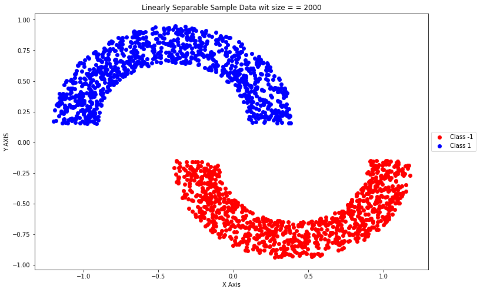

```python
data=generateDataset(Ndatapoints=1000, r=0.5, tk=0.3, sepp=-0.3)
Parameters=RExperforPLA(InitalWeight=np.zeros(3),SData=data,RunPLA=False,PlotTitle='Linearly Separable Sample Data wit size =')
```

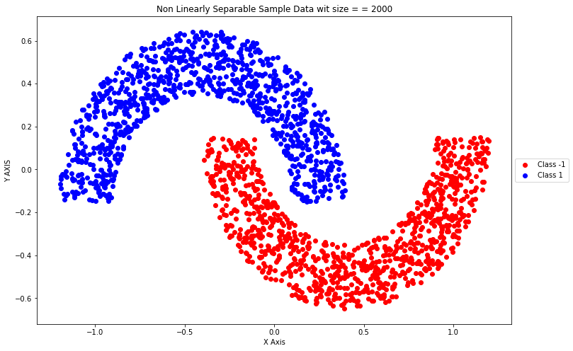

```python
data=generateDataset(Ndatapoints=1000, r=0.5, tk=0.3, sepp=0.3)
Parameters=RExperforPLA(InitalWeight=np.zeros(3),SData=data,RunPLA=False,PlotTitle='Non Linearly Separable Sample Data wit size =')
```

```
Number of updates taken before converging 6
PLA Algorithm run time: 0.0003seconds.
```

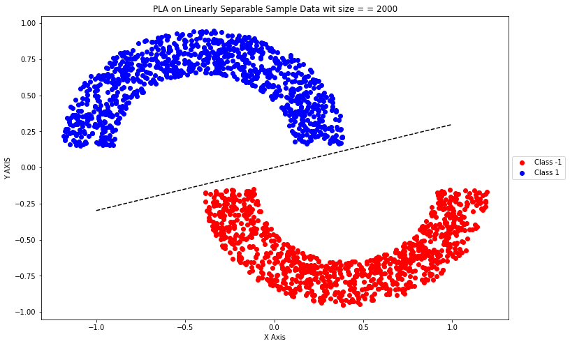

```python
data=generateDataset(Ndatapoints=1000, r=0.5, tk=0.3, sepp=-0.3)
Parameters=RExperforPLA(InitalWeight=np.zeros(3),SData=data,RunPLA=True,PlotTitle='PLA on Linearly Separable Sample Data wit size =')
```

```
Number of updates taken before converging 10000
PLA Algorithm run time: 0.5769seconds.
```

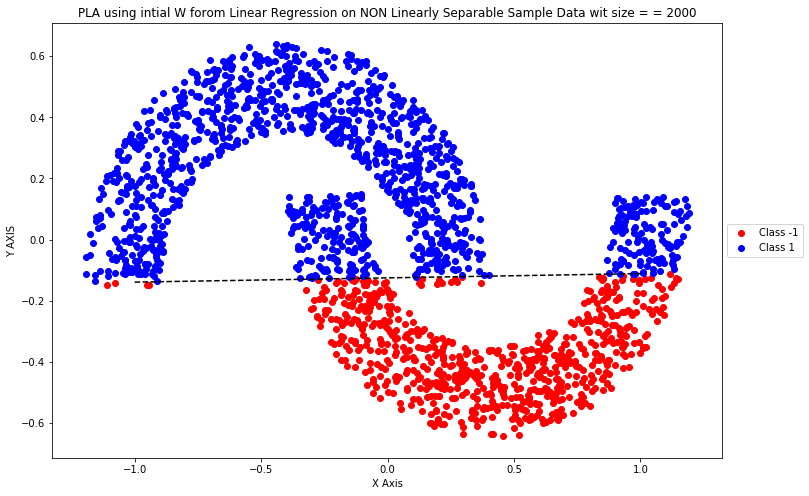

```python
from sklearn import datasets,linear_model
regr=linear_model.LinearRegression()
data=generateDataset(Ndatapoints=1000, r=0.5, tk=0.3, sepp=0.3)
RegressionVector=LinearRegression(Data=data[:,:3],TargetClassification=(np.transpose(data[:,3:][:]))[0])
Parameters=RExperforPLA(InitalWeight=RegressionVector,SData=data,RunPLA=True,PlotTitle='PLA using intial W forom Linear Regression on NON Linearly Separable Sample Data wit size =')
```

Since the dataset is not linearly separable, The PLA would continue for an infinite number of times ,adjusting w with each adjutment will cause one or more points to be misclassified,The PLA algorithm was force stopped at 10000 iterations.Otherwise it would continue to execute indeffinitely

```
Number of updates taken before converging 10000
PLA Algorithm run time: 0.5092seconds.
```

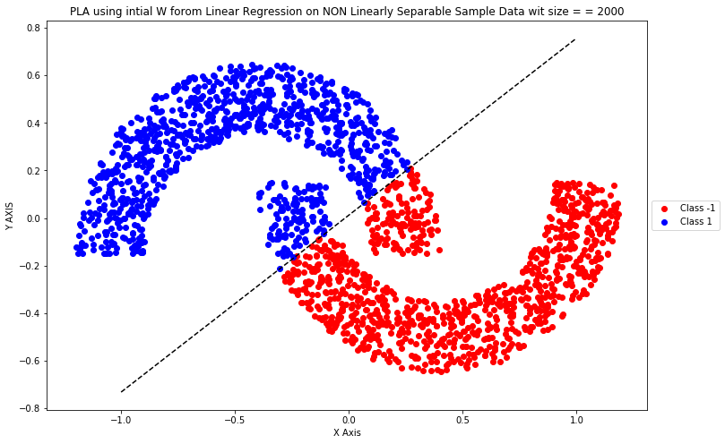

```python
data=generateDataset(Ndatapoints=1000, r=0.5, tk=0.3, sepp=0.3)
RegressionVector=LinearRegression(Data=data[:,:3],TargetClassification=(np.transpose(data[:,3:][:]))[0])
Parameters=RExperforPLA(InitalWeight=RegressionVector,SData=data,RunPLA=True,PlotTitle='PLA using intial W forom Linear Regression on NON Linearly Separable Sample Data wit size =')
```

Machine Learning Research Questions

$\bullet$ Can unlabeled data be helpful for supervised learning?  
e.g., learning to classify webpages or spam.  
unlabeled data in supervised learning can significantly improve learning accuracy in certain practical problems.

$\bullet$ How can we transfer what is learned for one task to improve learning in other related tasks?  
In Supervised Learning, it involves learning a single function f, but, our goal is to learn a family of functions that are related (e.g., a diagnosis function for patients in New York hospitals, and one for patients in US hospitals). How can we achieve this tasks?  
Hierarchical Bayesian approaches provide one way to tackle this problem.

$\bullet$ What is the best strategy for a learners that actively collect their own training data?

In the case of drug testing, one wishes to learn the drug effectiveness while minimizing the exposure of patients to possible unknown side effects.  
How Machine Learning Will Identify the Drugs Of The Future.  
Protein Folding Problem - how can you accurately predict the 3D structure of a protein from its amino acid sequence?

$\bullet$ Can we build never-ending learners?  
A program to learn to read the web might learn a graded set of capabilities. Some of the simpler abilities are learning to recognize names of people and places, and it can be extended such as extracting complex relational information spread across multiple sentences and web pages. Here, A reserch problem is self-supervised learning and constructing an appropriate graded curriculum.

$\bullet$ Can we design programming languages containing machine learning primitives?  
The objective is for designing programming language constructs for declaring what training experience should be given to each 'to be learned' subroutine, when, and with what safeguards against arbitrary changes to program behavior.